# Tarea 2 MAS

Pablo Escobar Hernández

5/31/2021

### *Cargamos librerías*

```r
library("readxl")
library(PerformanceAnalytics)
library(ggplot2)
library(mgcv)
library(lme4)
library(MASS)
datos <- read_excel("wine.xls", sheet = 1)
datos$AREA <- as.factor(datos$AREA)
```

```r
#ESCALAR POR SI FUERA NECESARIO
datos$WINTRAINs <- scale(datos$WINTRAIN)
datos$HARVRAINs <- scale(datos$HARVRAIN)
datos$SUMTEMPs <- scale(datos$SUMTEMP)
datos$SEPTEMPs <- scale(datos$SEPTEMP)
```

### *Descriptiva numérica*

**Summary de las variables cuantitativas:**

Observamos diferencias de escala importantes que podrían afectar al análisis, si vemos problemas consideraremos la posibilidad de escarlar las variables cuantitativas.

|  | Mínimo | Cuantil 1 | Mediana | Media | Cuantil 3 | Máximo | Desv. Est. |
| --- | --- | --- | --- | --- | --- | --- | --- |
| Price | 10.0 | 14.23439 | 18.50 | 25.80876 | 30.750 | 100.0 | 18.5725500 |
| Wintrain | 406.0 | 501.27500 | 611.85 | 630.84737 | 736.000 | 1050.2 | 150.6050082 |
| Harvrain | 18.0 | 93.00000 | 149.50 | 159.11579 | 217.750 | 420.0 | 87.0319156 |
| Sumtemp | 15.1 | 16.05000 | 16.49 | 16.50316 | 17.135 | 18.5 | 0.7721017 |
| Septemp | 14.3 | 16.60000 | 17.40 | 17.38947 | 18.350 | 20.4 | 1.2883657 |

**Summary de la variable cualitativa:**

|  | Área 1 | Área 2 | Área 3 |
| --- | --- | --- | --- |
| Área de producción | 13 | 10 | 15 |

**Gráficas de densidad de las variables:**

Observamos como la variable respuesta *PRICE* sigue una distribución Gamma o quizás una Normal si no fuera por unos pocos valores extremadamente altos que desplazan la gráfica.

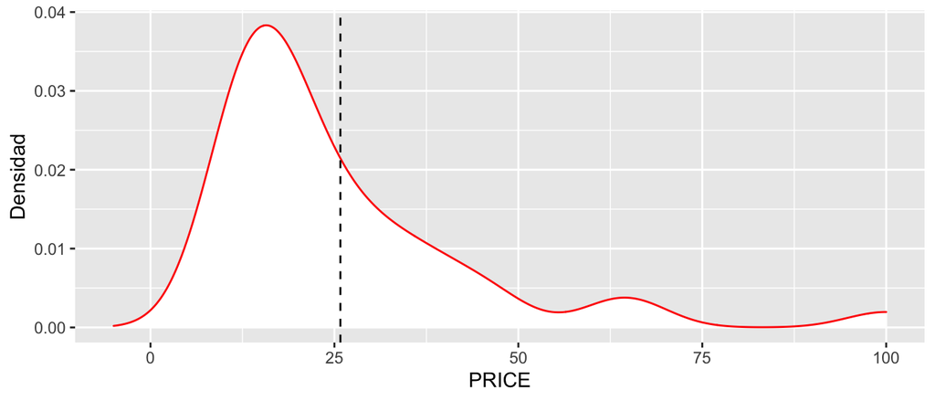

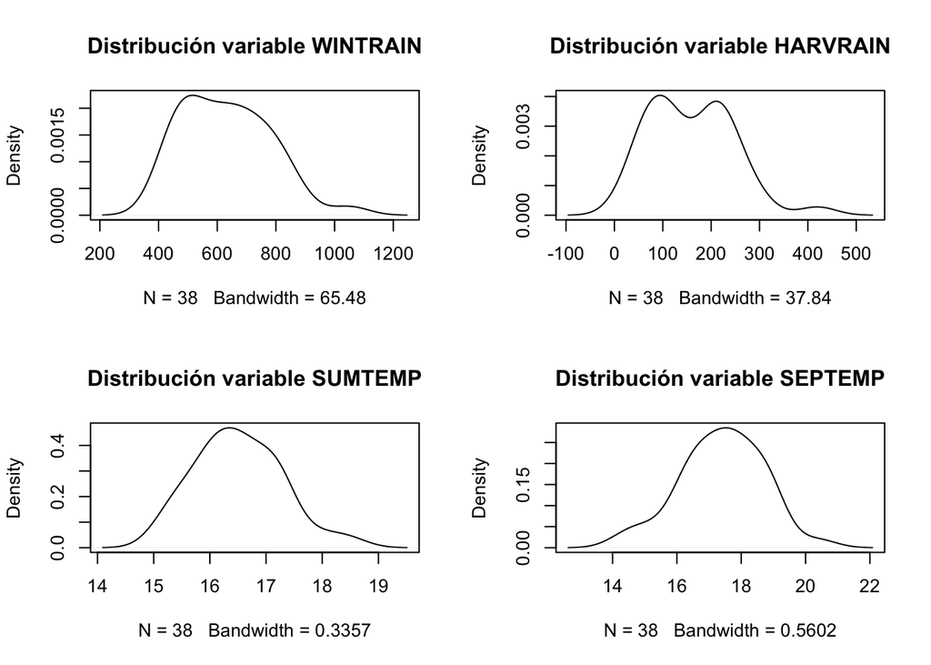

**Gráficas de los datos:**

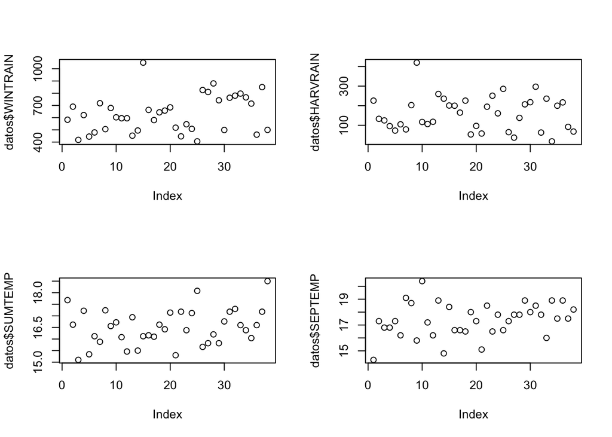

**Gráfica de correlación:**

Vemos correlación entre la variable respuesta PRICE y las variables explicartivas SUMTEMP y SEPTEMP, esperamos que formen parte del modelo final. Con el resto no está tan claro y la correlación con la variable respuesta es muy baja.

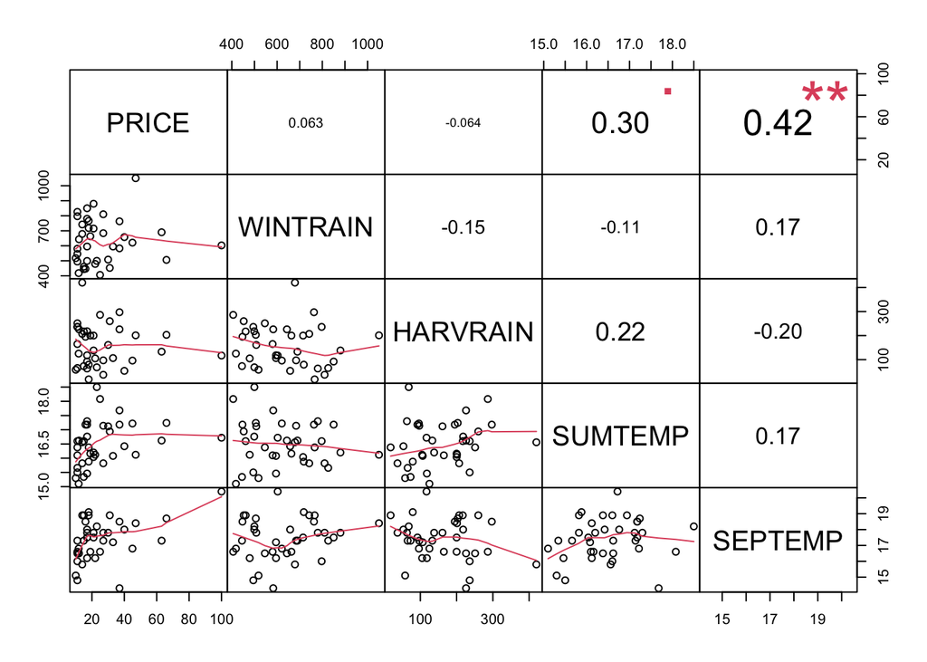

### *Modelo Lineal Normal*

**Modelo nulo:**

El modelo nulo tiene un AIC de 332.87.

```r
lmn <- lm(PRICE ~ 1, data=datos)
summary(lmn)
```

```
##
## Call:
## lm(formula = PRICE ~ 1, data = datos)
##
## Residuals:
##     Min      1Q  Median      3Q     Max
## -15.809 -11.574  -7.309   4.941  74.191
##
## Coefficients:
##             Estimate Std. Error t value Pr(>|t|)
## (Intercept)   25.809      3.013   8.566 2.61e-10 ***
## ---
## Signif. codes:  0 '***' 0.001 '**' 0.01 '*' 0.05 '.' 0.1 ' ' 1
##
## Residual standard error: 18.57 on 37 degrees of freedom
```

```r
AIC(lmn)
```

```
## [1] 332.874
```

**Empezamos probando un modelo saturado que incluye todas las variables:**

El AIC baja ligeramente a 314.96, la variable HARVRAIN no es significativa y las gráficas de los residuos no tienen mala pinta a excepción de algún valor extremo en la gráfica de normalidad.

```r
lm1 <- lm(PRICE ~ WINTRAIN + HARVRAIN + SUMTEMP + SEPTEMP + AREA, data=datos)
summary(lm1)
```

```
##
## Call:
## lm(formula = PRICE ~ WINTRAIN + HARVRAIN + SUMTEMP + SEPTEMP +
##     AREA, data = datos)
##
## Residuals:
##     Min      1Q  Median      3Q     Max
## -29.554  -8.143  -0.918   8.746  40.439
##
## Coefficients:
##               Estimate Std. Error t value Pr(>|t|)
## (Intercept) -2.387e+02  5.873e+01  -4.065 0.000305 ***
## WINTRAIN     2.964e-02  1.647e-02   1.800 0.081587 .
## HARVRAIN    -9.732e-03  2.754e-02  -0.353 0.726215
## SUMTEMP      9.524e+00  3.217e+00   2.961 0.005839 **
## SEPTEMP      5.996e+00  1.915e+00   3.132 0.003777 **
## AREA2       -1.395e+01  5.927e+00  -2.353 0.025165 *
## AREA3       -2.632e+01  5.756e+00  -4.573 7.27e-05 ***
## ---
## Signif. codes:  0 '***' 0.001 '**' 0.01 '*' 0.05 '.' 0.1 ' ' 1
##
## Residual standard error: 13.69 on 31 degrees of freedom
## Multiple R-squared:  0.5448, Adjusted R-squared:  0.4567
## F-statistic: 6.185 on 6 and 31 DF,  p-value: 0.0002384
```

```r
AIC(lm1)
```

```
## [1] 314.9636
```

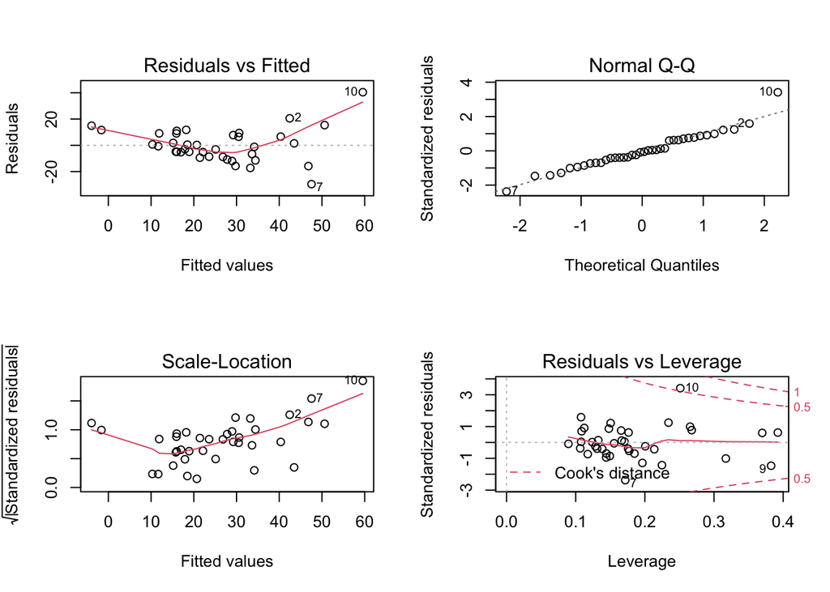

```r
par(mfrow=c(2,2))
plot(lm1)
```

**Modelo lineal final quitando la variable HARVRAIN:**

Misma situación para los resiudos, le pasamos un test de normalidad y no podemos rechazar la hipótesis de que no sean normales pero el p valor no es demasiado alto (0.22). En este caso el AIC es de 313 y el p valor de WINTRAIN es de 0.07.

```r
lmf <- lm(formula = PRICE ~ WINTRAIN + SUMTEMP + SEPTEMP + AREA, data = datos)
summary(lmf)
```

```
##
## Call:
## lm(formula = PRICE ~ WINTRAIN + SUMTEMP + SEPTEMP + AREA, data = datos)
##
## Residuals:
##     Min      1Q  Median      3Q     Max
## -29.251  -7.314  -0.425   8.017  40.477
##
## Coefficients:
##               Estimate Std. Error t value Pr(>|t|)
## (Intercept) -238.34193   57.91089  -4.116 0.000253 ***
## WINTRAIN       0.03011    0.01619   1.860 0.072165 .
## SUMTEMP        9.23764    3.07008   3.009 0.005078 **
## SEPTEMP        6.14052    1.84477   3.329 0.002205 **
## AREA2        -14.02385    5.84174  -2.401 0.022354 *
## AREA3        -26.29939    5.67599  -4.633 5.75e-05 ***
## ---
## Signif. codes:  0 '***' 0.001 '**' 0.01 '*' 0.05 '.' 0.1 ' ' 1
##
## Residual standard error: 13.5 on 32 degrees of freedom
## Multiple R-squared:  0.543,  Adjusted R-squared:  0.4716
## F-statistic: 7.605 on 5 and 32 DF,  p-value: 8.393e-05
```

```r
AIC(lmf)
```

```
## [1] 313.1164
```

```r
shapiro.test(lmf$residuals)
```

```
##
##  Shapiro-Wilk normality test
##
## data:  lmf$residuals
## W = 0.96207, p-value = 0.2216
```

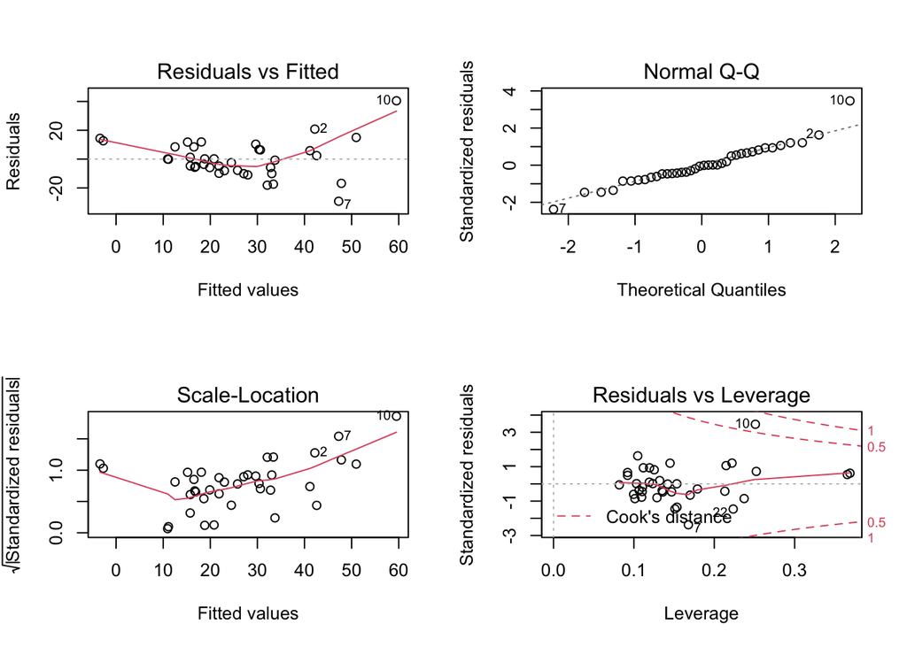

```r
par(mfrow=c(2,2))
plot(lmf)
```

**Probamos modelos con diferentes interacciones:**

Ninguna de las interacciones sale significativa así que no las incluiremos.

```r
lmi1 <- lm(formula = PRICE ~ (WINTRAIN * HARVRAIN) + SEPTEMP + SUMTEMP + AREA, data = datos)
summary(lmi1)
```

```
##
## Call:
## lm(formula = PRICE ~ (WINTRAIN * HARVRAIN) + SEPTEMP + SUMTEMP +
##     AREA, data = datos)
##
## Residuals:
##     Min      1Q  Median      3Q     Max
## -28.995  -7.698  -0.742   8.224  40.266
##
## Coefficients:
##                     Estimate Std. Error t value Pr(>|t|)
## (Intercept)       -2.341e+02  6.154e+01  -3.803 0.000654 ***
## WINTRAIN           1.817e-02  4.119e-02   0.441 0.662194
## HARVRAIN          -5.339e-02  1.460e-01  -0.366 0.717190
## SEPTEMP            6.023e+00  1.945e+00   3.096 0.004226 **
## SUMTEMP            9.661e+00  3.296e+00   2.931 0.006399 **
## AREA2             -1.378e+01  6.041e+00  -2.281 0.029812 *
## AREA3             -2.583e+01  6.063e+00  -4.260 0.000186 ***
## WINTRAIN:HARVRAIN  6.663e-05  2.187e-04   0.305 0.762751
## ---
## Signif. codes:  0 '***' 0.001 '**' 0.01 '*' 0.05 '.' 0.1 ' ' 1
##
## Residual standard error: 13.89 on 30 degrees of freedom
## Multiple R-squared:  0.5462, Adjusted R-squared:  0.4404
## F-statistic: 5.159 on 7 and 30 DF,  p-value: 0.0006167
```

```r
AIC(lmi1)
```

```
## [1] 316.8462
```

```r
lmi2 <- lm(formula = PRICE ~ WINTRAIN + (HARVRAIN * SEPTEMP) + SUMTEMP + AREA, data = datos)
summary(lmi2)
```

```
##
## Call:
## lm(formula = PRICE ~ WINTRAIN + (HARVRAIN * SEPTEMP) + SUMTEMP +
##     AREA, data = datos)
##
## Residuals:
##     Min      1Q  Median      3Q     Max
## -28.086  -6.754  -1.170   8.383  42.026
##
## Coefficients:
##                    Estimate Std. Error t value Pr(>|t|)
## (Intercept)      -212.35520   81.93991  -2.592  0.01461 *
## WINTRAIN            0.03173    0.01727   1.838  0.07601 .
## HARVRAIN           -0.18459    0.37470  -0.493  0.62586
## SEPTEMP             4.13102    4.43234   0.932  0.35877
## SUMTEMP             9.82178    3.31954   2.959  0.00598 **
## AREA2             -14.43876    6.09546  -2.369  0.02448 *
## AREA3             -26.75987    5.90386  -4.533 8.69e-05 ***
## HARVRAIN:SEPTEMP    0.01018    0.02176   0.468  0.64319
## ---
## Signif. codes:  0 '***' 0.001 '**' 0.01 '*' 0.05 '.' 0.1 ' ' 1
##
## Residual standard error: 13.86 on 30 degrees of freedom
## Multiple R-squared:  0.5481, Adjusted R-squared:  0.4427
## F-statistic: 5.199 on 7 and 30 DF,  p-value: 0.0005837
```

```r
AIC(lmi2)
```

```
## [1] 316.6872
```

```r
lmi3 <- lm(formula = PRICE ~ WINTRAIN + HARVRAIN + (SEPTEMP * SUMTEMP) + AREA, data = datos)
summary(lmi3)
```

```
##
## Call:
## lm(formula = PRICE ~ WINTRAIN + HARVRAIN + (SEPTEMP * SUMTEMP) +
##     AREA, data = datos)
##
## Residuals:
##     Min      1Q  Median      3Q     Max
## -27.216  -7.193  -0.835   9.282  39.391
##
## Coefficients:
##                   Estimate Std. Error t value Pr(>|t|)
## (Intercept)     335.839635 731.250757   0.459   0.6494
## WINTRAIN          0.035403   0.018109   1.955   0.0600 .
## HARVRAIN         -0.006927   0.027940  -0.248   0.8059
## SEPTEMP         -28.058076  43.241968  -0.649   0.5214
## SUMTEMP         -25.271425  44.257718  -0.571   0.5722
## AREA2           -15.661783   6.349026  -2.467   0.0196 *
## AREA3           -27.272389   5.915033  -4.611 6.98e-05 ***
## SEPTEMP:SUMTEMP   2.049811   2.600262   0.788   0.4367
## ---
## Signif. codes:  0 '***' 0.001 '**' 0.01 '*' 0.05 '.' 0.1 ' ' 1
##
## Residual standard error: 13.77 on 30 degrees of freedom
## Multiple R-squared:  0.5541, Adjusted R-squared:   0.45
## F-statistic: 5.325 on 7 and 30 DF,  p-value: 0.0004902
```

```r
AIC(lmi3)
```

```
## [1] 316.1845
```

```r
lmi4 <- lm(formula = PRICE ~ (WINTRAIN * SEPTEMP) +  HARVRAIN + SUMTEMP + AREA, data = datos)
summary(lmi4)
```

```
##
## Call:
## lm(formula = PRICE ~ (WINTRAIN * SEPTEMP) + HARVRAIN + SUMTEMP +
##     AREA, data = datos)
##
## Residuals:
##     Min      1Q  Median      3Q     Max
## -31.575  -7.772  -0.043   5.856  40.140
##
## Coefficients:
##                    Estimate Std. Error t value Pr(>|t|)
## (Intercept)      -78.681180 182.532546  -0.431  0.66951
## WINTRAIN          -0.261007   0.314210  -0.831  0.41272
## SEPTEMP           -3.759410  10.705190  -0.351  0.72791
## HARVRAIN          -0.005879   0.027918  -0.211  0.83463
## SUMTEMP           10.243806   3.316390   3.089  0.00431 **
## AREA2            -14.741616   6.002953  -2.456  0.02007 *
## AREA3            -26.442093   5.770273  -4.582 7.55e-05 ***
## WINTRAIN:SEPTEMP   0.016426   0.017732   0.926  0.36168
## ---
## Signif. codes:  0 '***' 0.001 '**' 0.01 '*' 0.05 '.' 0.1 ' ' 1
##
## Residual standard error: 13.72 on 30 degrees of freedom
## Multiple R-squared:  0.5575, Adjusted R-squared:  0.4542
## F-statistic:   5.4 on 7 and 30 DF,  p-value: 0.0004427
```

```r
AIC(lmi4)
```

```
## [1] 315.892
```

```r
lmi5 <- lm(formula = PRICE ~ (WINTRAIN * SUMTEMP) +  HARVRAIN + SEPTEMP + AREA, data = datos)
summary(lmi5)
```

```
##
## Call:
## lm(formula = PRICE ~ (WINTRAIN * SUMTEMP) + HARVRAIN + SEPTEMP +
##     AREA, data = datos)
##
## Residuals:
##     Min      1Q  Median      3Q     Max
## -30.335  -7.283  -1.977   8.422  40.797
##
## Coefficients:
##                    Estimate Std. Error t value Pr(>|t|)
## (Intercept)      -3.187e+02  2.165e+02  -1.472  0.15132
## WINTRAIN          1.771e-01  3.839e-01   0.461  0.64794
## SUMTEMP           1.458e+01  1.355e+01   1.076  0.29045
## HARVRAIN         -1.119e-02  2.819e-02  -0.397  0.69411
## SEPTEMP           5.838e+00  1.984e+00   2.942  0.00623 **
## AREA2            -1.423e+01  6.056e+00  -2.350  0.02556 *
## AREA3            -2.672e+01  5.926e+00  -4.509 9.29e-05 ***
## WINTRAIN:SUMTEMP -8.966e-03  2.332e-02  -0.384  0.70338
## ---
## Signif. codes:  0 '***' 0.001 '**' 0.01 '*' 0.05 '.' 0.1 ' ' 1
##
## Residual standard error: 13.88 on 30 degrees of freedom
## Multiple R-squared:  0.5471, Adjusted R-squared:  0.4414
## F-statistic: 5.177 on 7 and 30 DF,  p-value: 0.0006021
```

```r
AIC(lmi5)
```

```
## [1] 316.7769
```

```r
lmi6 <- lm(formula = PRICE ~ WINTRAIN + (SUMTEMP *  HARVRAIN) + SEPTEMP + AREA, data = datos)
summary(lmi6)
```

```
##
## Call:
## lm(formula = PRICE ~ WINTRAIN + (SUMTEMP * HARVRAIN) + SEPTEMP +
##     AREA, data = datos)
##
## Residuals:
##     Min      1Q  Median      3Q     Max
## -30.564  -7.048  -1.546   6.042  40.689
##
## Coefficients:
##                    Estimate Std. Error t value Pr(>|t|)
## (Intercept)      -180.43164  100.52151  -1.795  0.08274 .
## WINTRAIN            0.03169    0.01684   1.882  0.06963 .
## SUMTEMP             5.76810    6.15711   0.937  0.35633
## HARVRAIN           -0.47480    0.64875  -0.732  0.46992
## SEPTEMP             6.12889    1.93865   3.161  0.00358 **
## AREA2             -13.06378    6.09941  -2.142  0.04045 *
## AREA3             -26.34206    5.80125  -4.541 8.49e-05 ***
## SUMTEMP:HARVRAIN    0.02797    0.03899   0.718  0.47859
## ---
## Signif. codes:  0 '***' 0.001 '**' 0.01 '*' 0.05 '.' 0.1 ' ' 1
##
## Residual standard error: 13.8 on 30 degrees of freedom
## Multiple R-squared:  0.5525, Adjusted R-squared:  0.4481
## F-statistic: 5.292 on 7 and 30 DF,  p-value: 0.0005133
```

```r
AIC(lmi6)
```

```
## [1] 316.317
```

### *Modelo Lineal Generalizado con Distribución Gamma*

**Empezamos probando un modelo saturado que incluye todas las variables:**

Misma situación que en el caos anterior pero con un AIC más bajo de 278, la normalidad de los residuos peor que ants. La variabel HARVRAIN de nuevo no significativa.

```r
glm1 <- glm(formula = PRICE ~ WINTRAIN + HARVRAIN + SUMTEMP + SEPTEMP + AREA,  family  = Gamma(link = "log"),data = datos)
summary(glm1)
```

```
##
## Call:
## glm(formula = PRICE ~ WINTRAIN + HARVRAIN + SUMTEMP + SEPTEMP +
##     AREA, family = Gamma(link = "log"), data = datos)
##
## Deviance Residuals:
##      Min        1Q    Median        3Q       Max
## -0.76887  -0.31056  -0.04709   0.28070   0.49693
##
## Coefficients:
##               Estimate Std. Error t value Pr(>|t|)
## (Intercept) -6.5400701  1.6235628  -4.028 0.000338 ***
## WINTRAIN     0.0011565  0.0004552   2.540 0.016296 *
## HARVRAIN    -0.0005648  0.0007614  -0.742 0.463822
## SUMTEMP      0.3931054  0.0889237   4.421 0.000112 ***
## SEPTEMP      0.1719122  0.0529298   3.248 0.002793 **
## AREA2       -0.4793439  0.1638633  -2.925 0.006386 **
## AREA3       -0.8042902  0.1591124  -5.055 1.84e-05 ***
## ---
## Signif. codes:  0 '***' 0.001 '**' 0.01 '*' 0.05 '.' 0.1 ' ' 1
##
## (Dispersion parameter for Gamma family taken to be 0.1432086)
##
##     Null deviance: 13.597  on 37  degrees of freedom
## Residual deviance:  4.649  on 31  degrees of freedom
## AIC: 278.24
##
## Number of Fisher Scoring iterations: 7
```

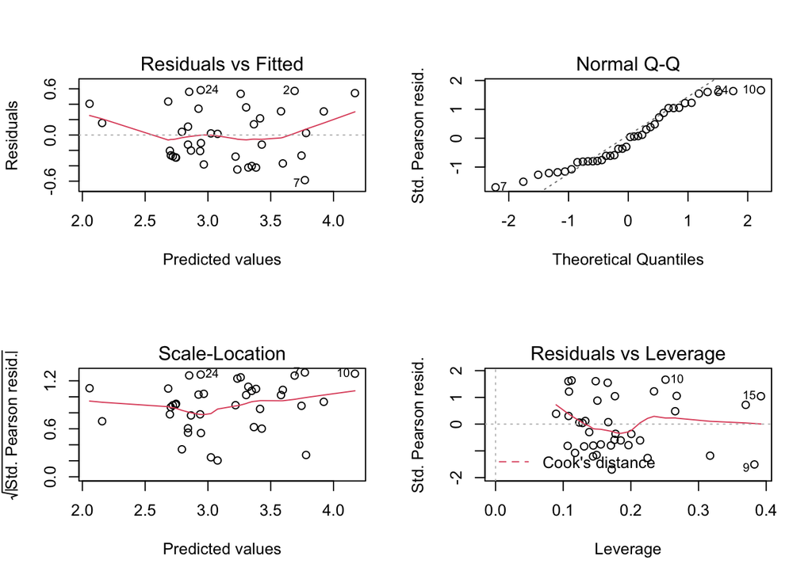

```r
par(mfrow=c(2,2))
plot(glm1)
```

**Modelo lineal final sin la variable HARVRAIN:**

Obtenemos un AIC de 276.8, todos los coeficientes significativos, la normalidad un desastre.

```r
glmf <- glm(formula = PRICE ~ WINTRAIN + SUMTEMP + SEPTEMP + AREA, family = Gamma(link = "log"), data = datos) #AIC: 276.8
summary(glmf)
```

```
##
## Call:
## glm(formula = PRICE ~ WINTRAIN + SUMTEMP + SEPTEMP + AREA, family = Gamma(link = "log"),
##     data = datos)
##
## Deviance Residuals:
##      Min        1Q    Median        3Q       Max
## -0.75947  -0.33438  -0.03447   0.23907   0.53954
##
## Coefficients:
##               Estimate Std. Error t value Pr(>|t|)
## (Intercept) -6.4331653  1.6119166  -3.991 0.000359 ***
## WINTRAIN     0.0011840  0.0004506   2.627 0.013097 *
## SUMTEMP      0.3733004  0.0854540   4.368 0.000123 ***
## SEPTEMP      0.1787673  0.0513481   3.481 0.001464 **
## AREA2       -0.4877461  0.1626015  -3.000 0.005199 **
## AREA3       -0.8127927  0.1579878  -5.145  1.3e-05 ***
## ---
## Signif. codes:  0 '***' 0.001 '**' 0.01 '*' 0.05 '.' 0.1 ' ' 1
##
## (Dispersion parameter for Gamma family taken to be 0.14121)
##
##     Null deviance: 13.5970  on 37  degrees of freedom
## Residual deviance:  4.7171  on 32  degrees of freedom
## AIC: 276.8
##
## Number of Fisher Scoring iterations: 6
```

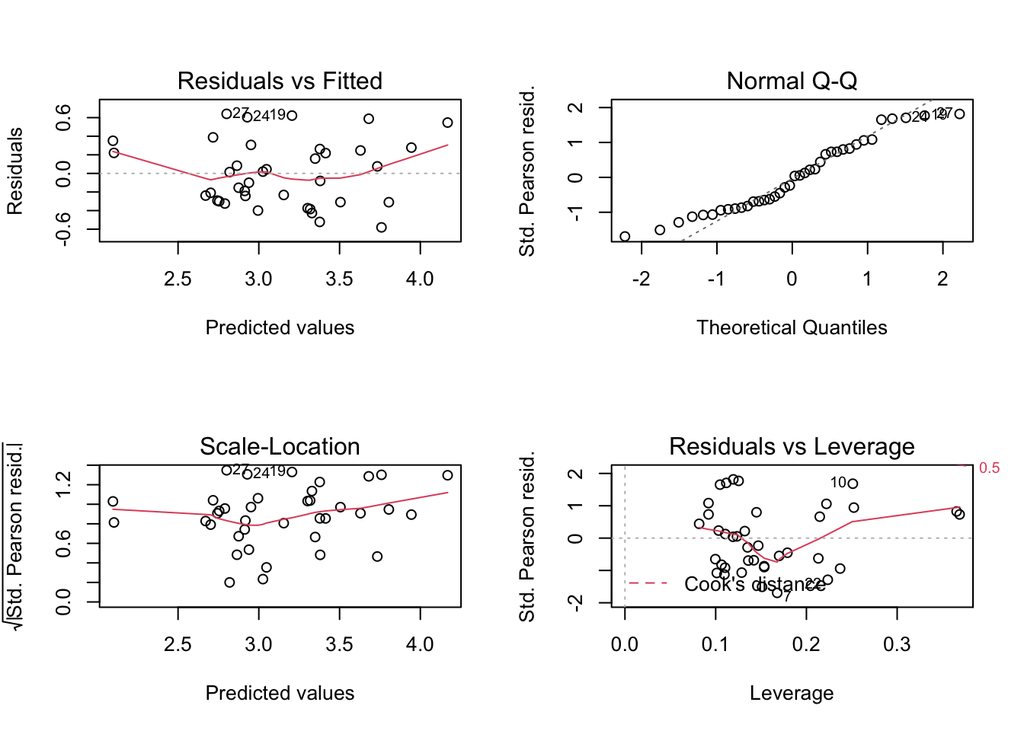

```r
par(mfrow=c(2,2))
plot(glmf)
```

**Probamos escalando las variables cuantitativas**:

De nuevo, HARVRAIN sigue sin tener un efecto significativo, AIC de 278 y seguimos sin tener normalidad en los residuos.

```r
glm1s <- glm(formula = PRICE ~ WINTRAINs + SUMTEMPs + SEPTEMPs + AREA + HARVRAINs,  family  = Gamma(link = "log"),data = datos)
summary(glm1s)
```

```
##
## Call:
## glm(formula = PRICE ~ WINTRAINs + SUMTEMPs + SEPTEMPs + AREA +
##     HARVRAINs, family = Gamma(link = "log"), data = datos)
##
## Deviance Residuals:
##      Min        1Q    Median        3Q       Max
## -0.76887  -0.31056  -0.04709   0.28070   0.49693
##
## Coefficients:
##             Estimate Std. Error t value Pr(>|t|)
## (Intercept)  3.57660    0.10973  32.594  < 2e-16 ***
## WINTRAINs    0.17418    0.06856   2.540 0.016296 *
## SUMTEMPs     0.30352    0.06866   4.421 0.000112 ***
## SEPTEMPs     0.22149    0.06819   3.248 0.002793 **
## AREA2       -0.47934    0.16386  -2.925 0.006386 **
## AREA3       -0.80429    0.15911  -5.055 1.84e-05 ***
## HARVRAINs   -0.04915    0.06627  -0.742 0.463822
## ---
## Signif. codes:  0 '***' 0.001 '**' 0.01 '*' 0.05 '.' 0.1 ' ' 1
##
## (Dispersion parameter for Gamma family taken to be 0.1432086)
##
##     Null deviance: 13.597  on 37  degrees of freedom
## Residual deviance:  4.649  on 31  degrees of freedom
## AIC: 278.24
##
## Number of Fisher Scoring iterations: 7
```

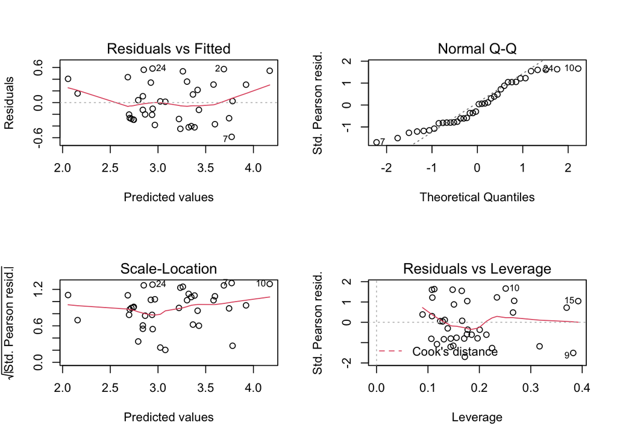

```r
par(mfrow=c(2,2))
plot(glm1s)
```

Todos los coeficientes significativos, AIC de 276.8 y normalidad de los residuos mala.

```r
glmfs <- glm(formula = PRICE ~ WINTRAIN + SUMTEMP + SEPTEMP + AREA, family = Gamma(link = "log"), data = datos)
summary(glmfs)
```

```
##
## Call:
## glm(formula = PRICE ~ WINTRAIN + SUMTEMP + SEPTEMP + AREA, family = Gamma(link = "log"),
##     data = datos)
##
## Deviance Residuals:
##      Min        1Q    Median        3Q       Max
## -0.75947  -0.33438  -0.03447   0.23907   0.53954
##
## Coefficients:
##               Estimate Std. Error t value Pr(>|t|)
## (Intercept) -6.4331653  1.6119166  -3.991 0.000359 ***
## WINTRAIN     0.0011840  0.0004506   2.627 0.013097 *
## SUMTEMP      0.3733004  0.0854540   4.368 0.000123 ***
## SEPTEMP      0.1787673  0.0513481   3.481 0.001464 **
## AREA2       -0.4877461  0.1626015  -3.000 0.005199 **
## AREA3       -0.8127927  0.1579878  -5.145  1.3e-05 ***
## ---
## Signif. codes:  0 '***' 0.001 '**' 0.01 '*' 0.05 '.' 0.1 ' ' 1
##
## (Dispersion parameter for Gamma family taken to be 0.14121)
##
##     Null deviance: 13.5970  on 37  degrees of freedom
## Residual deviance:  4.7171  on 32  degrees of freedom
## AIC: 276.8
##
## Number of Fisher Scoring iterations: 6
```

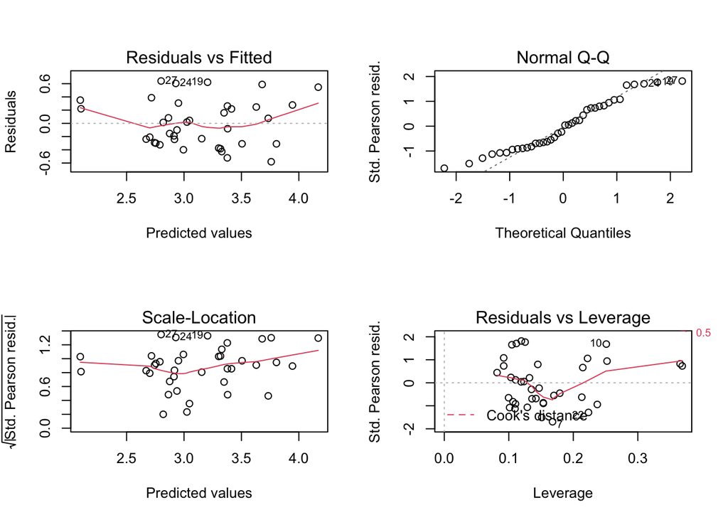

```r
par(mfrow=c(2,2))
plot(glmfs)
```

### *Modelo Lineal Mixto*

He probado a meter como factor de efectos aleatoriso la variable AREA, obteniendo un AIC de 322. Los coeficientes para HARVRAIN y WINTRAIN salen no significativos.

**Modelo lineal mixto con todas las variables y AREA como efecto aleatorio:**

Seguimos con la misma dinámica, HARVRAIN y WINTRAIN no tienen un efecto significativo y tenemos un AIC de 321.

```r
Mlme1 <- lme(PRICE ~  HARVRAIN + SUMTEMP + SEPTEMP + WINTRAIN, random = ~ 1 | AREA, data = datos)
summary(Mlme1)
```

```
## Linear mixed-effects model fit by REML
##  Data: datos
##        AIC     BIC    logLik
##   321.7685 332.244 -153.8842
##
## Random effects:
##  Formula: ~1 | AREA
##         (Intercept) Residual
## StdDev:    12.56765 13.68638
##
## Fixed effects: PRICE ~ HARVRAIN + SUMTEMP + SEPTEMP + WINTRAIN
##                  Value Std.Error DF   t-value p-value
## (Intercept) -243.88865  59.12681 31 -4.124841  0.0003
## HARVRAIN      -0.00962   0.02753 31 -0.349298  0.7292
## SUMTEMP        9.18821   3.20375 31  2.867957  0.0074
## SEPTEMP        5.92721   1.90835 31  3.105930  0.0040
## WINTRAIN       0.02710   0.01637 31  1.655868  0.1078
##  Correlation:
##          (Intr) HARVRA SUMTEM SEPTEM
## HARVRAIN  0.016
## SUMTEMP  -0.805 -0.252
## SEPTEMP  -0.391  0.215 -0.181
## WINTRAIN -0.273  0.080  0.184 -0.127
##
## Standardized Within-Group Residuals:
##         Min          Q1         Med          Q3         Max
## -2.05297641 -0.56251858 -0.07187483  0.57426306  3.06645329
##
## Number of Observations: 38
## Number of Groups: 3
```

**Modelo lineal mixto sin las variables HARVRAIN y WINTRAIN y con la variable AREA como efecto aleatorio:**

Todos los coeficientes significativos, AIC de 309.

```r
Mlme2 <- lme(PRICE ~  SUMTEMP + SEPTEMP , random = ~ 1 | AREA, data = datos)
summary(Mlme2)
```

```
## Linear mixed-effects model fit by REML
##  Data: datos
##        AIC      BIC   logLik
##   308.8961 316.6728 -149.448
##
## Random effects:
##  Formula: ~1 | AREA
##         (Intercept) Residual
## StdDev:    10.68358 13.98733
##
## Fixed effects: PRICE ~ SUMTEMP + SEPTEMP
##                  Value Std.Error DF   t-value p-value
## (Intercept) -214.16426  57.80565 33 -3.704902  0.0008
## SUMTEMP        7.71949   3.09370 33  2.495230  0.0178
## SEPTEMP        6.50082   1.88037 33  3.457201  0.0015
##  Correlation:
##         (Intr) SUMTEM
## SUMTEMP -0.820
## SEPTEMP -0.468 -0.109
##
## Standardized Within-Group Residuals:
##         Min          Q1         Med          Q3         Max
## -1.77286147 -0.59424559 -0.07438083  0.55714258  3.02180360
##
## Number of Observations: 38
## Number of Groups: 3
```

### *Modelo Lineal Generalizado Mixto*

**Modelo lineal generalizado mixto con todas las variables y AREA como efecto aleatorio:**

Probamos introduciendo un efecto aleatorio sobre la variable AREA y, como viene siendo habitual, la variable HARVRAIN sale no significativa. Este modelo no da una estimación del AIC.

```r
GLMM1 <- glmmPQL(PRICE ~  HARVRAIN + SUMTEMP + SEPTEMP + WINTRAIN, random = ~ 1 | AREA, data = datos, family = Gamma(link="log"))
```

```
## iteration 1
```

```
## iteration 2
```

```
## iteration 3
```

```
## iteration 4
```

```r
summary(GLMM1)
```

```
## Linear mixed-effects model fit by maximum likelihood
##  Data: datos
##   AIC BIC logLik
##    NA  NA     NA
##
## Random effects:
##  Formula: ~1 | AREA
##         (Intercept)  Residual
## StdDev:    0.313634 0.3567101
##
## Variance function:
##  Structure: fixed weights
##  Formula: ~invwt
## Fixed effects: PRICE ~ HARVRAIN + SUMTEMP + SEPTEMP + WINTRAIN
##                 Value Std.Error DF   t-value p-value
## (Intercept) -6.813760 1.6515362 31 -4.125711  0.0003
## HARVRAIN    -0.000604 0.0007701 31 -0.784127  0.4389
## SUMTEMP      0.387966 0.0895746 31  4.331201  0.0001
## SEPTEMP      0.170850 0.0533596 31  3.201856  0.0031
## WINTRAIN     0.001084 0.0004575 31  2.370037  0.0242
##  Correlation:
##          (Intr) HARVRA SUMTEM SEPTEM
## HARVRAIN  0.016
## SUMTEMP  -0.805 -0.252
## SEPTEMP  -0.391  0.216 -0.182
## WINTRAIN -0.273  0.080  0.184 -0.128
##
## Standardized Within-Group Residuals:
##        Min         Q1        Med         Q3        Max
## -1.5880339 -0.8318843 -0.1059055  0.9145048  1.8141264
##
## Number of Observations: 38
## Number of Groups: 3
```

**Modelo lineal generalizado mixto sin la variable HARVRAIN y con la variable AREA como efecto aleatorio:**

Al eliminar la variable HARVRAIN todas las que quedan son significativas pero no tenemos una estimación de si el AIC es mejor o no.

```r
GLMM2 <- glmmPQL(PRICE ~ SUMTEMP + SEPTEMP + WINTRAIN, random = ~ 1 | AREA, data = datos, family = Gamma(link="log"))
```

```
## iteration 1
```

```
## iteration 2
```

```
## iteration 3
```

```
## iteration 4
```

```r
summary(GLMM2)
```

```
## Linear mixed-effects model fit by maximum likelihood
##  Data: datos
##   AIC BIC logLik
##    NA  NA     NA
##
## Random effects:
##  Formula: ~1 | AREA
##         (Intercept)  Residual
## StdDev:   0.3174099 0.3605226
##
## Variance function:
##  Structure: fixed weights
##  Formula: ~invwt
## Fixed effects: PRICE ~ SUMTEMP + SEPTEMP + WINTRAIN
##                 Value Std.Error DF   t-value p-value
## (Intercept) -6.698343 1.6443147 32 -4.073638  0.0003
## SUMTEMP      0.366431 0.0863147 32  4.245294  0.0002
## SEPTEMP      0.178212 0.0518826 32  3.434912  0.0017
## WINTRAIN     0.001111 0.0004540 32  2.446128  0.0201
##  Correlation:
##          (Intr) SUMTEM SEPTEM
## SUMTEMP  -0.828
## SEPTEMP  -0.404 -0.135
## WINTRAIN -0.275  0.211 -0.149
##
## Standardized Within-Group Residuals:
##        Min         Q1        Med         Q3        Max
## -1.5548214 -0.8241334 -0.1370870  0.7485246  1.8454045
##
## Number of Observations: 38
## Number of Groups: 3
```

### *Modelos Aditivos Generalizados con Distribución Gamma*

**Modelo con todas las variables menos WINTRAIN suavizadas:**

```r
MG1<-gam(PRICE ~ WINTRAIN + s(HARVRAIN) + s(SUMTEMP) + s(SEPTEMP) + AREA, family=Gamma(link=log), data=datos)
summary(MG1)
```

```
##
## Family: Gamma
## Link function: log
##
## Formula:
## PRICE ~ WINTRAIN + s(HARVRAIN) + s(SUMTEMP) + s(SEPTEMP) + AREA
##
## Parametric coefficients:
##               Estimate Std. Error t value Pr(>|t|)
## (Intercept)  2.9674886  0.2231617  13.297 9.06e-12 ***
## WINTRAIN     0.0011430  0.0003705   3.085 0.005560 **
## AREA2       -0.6663036  0.1716953  -3.881 0.000849 ***
## AREA3       -1.0600339  0.1726742  -6.139 4.11e-06 ***
## ---
## Signif. codes:  0 '***' 0.001 '**' 0.01 '*' 0.05 '.' 0.1 ' ' 1
##
## Approximate significance of smooth terms:
##               edf Ref.df      F  p-value
## s(HARVRAIN) 6.460  7.472  1.987   0.0956 .
## s(SUMTEMP)  1.000  1.000 22.928 7.54e-05 ***
## s(SEPTEMP)  5.298  6.272  3.530   0.0130 *
## ---
## Signif. codes:  0 '***' 0.001 '**' 0.01 '*' 0.05 '.' 0.1 ' ' 1
##
## R-sq.(adj) =   0.83   Deviance explained = 87.2%
## GCV = 0.14697  Scale est. = 0.078638  n = 38
```

```r
AIC(MG1)
```

```
## [1] 260.0351
```

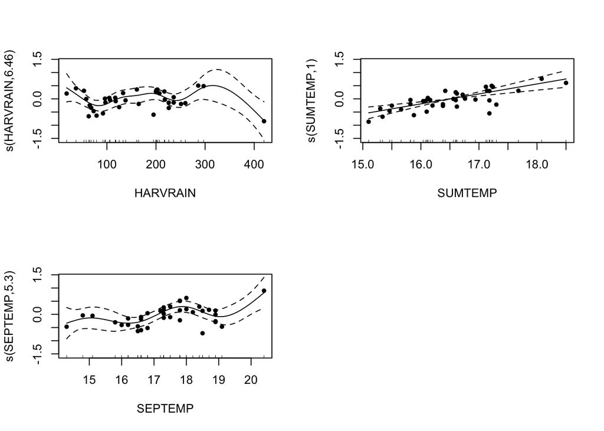

```r
par(mfrow=c(2,2))
plot(MG1,residuals=TRUE,pch=20)
```

**Modelo quitando el suavizado para SUMTEMP y poniéndolo para WINTRAIN:**

```r
MG2<-gam(PRICE ~  s(WINTRAIN) +  s(HARVRAIN) + SUMTEMP + s(SEPTEMP) + AREA, family=Gamma(link=log), data=datos)
summary(MG2)
```

```
##
## Family: Gamma
## Link function: log
##
## Formula:
## PRICE ~ s(WINTRAIN) + s(HARVRAIN) + SUMTEMP + s(SEPTEMP) + AREA
##
## Parametric coefficients:
##             Estimate Std. Error t value Pr(>|t|)
## (Intercept) -2.07541    1.27964  -1.622 0.121745
## SUMTEMP      0.34588    0.07876   4.391 0.000332 ***
## AREA2       -0.70940    0.16654  -4.260 0.000446 ***
## AREA3       -0.90409    0.18715  -4.831 0.000125 ***
## ---
## Signif. codes:  0 '***' 0.001 '**' 0.01 '*' 0.05 '.' 0.1 ' ' 1
##
## Approximate significance of smooth terms:
##               edf Ref.df     F p-value
## s(WINTRAIN) 3.592  4.352 3.412  0.0266 *
## s(HARVRAIN) 6.774  7.721 2.296  0.0671 .
## s(SEPTEMP)  5.131  6.036 3.456  0.0181 *
## ---
## Signif. codes:  0 '***' 0.001 '**' 0.01 '*' 0.05 '.' 0.1 ' ' 1
##
## R-sq.(adj) =  0.845   Deviance explained = 90.3%
## GCV = 0.14665  Scale est. = 0.071547  n = 38
```

```r
AIC(MG2)
```

```
## [1] 254.8684
```

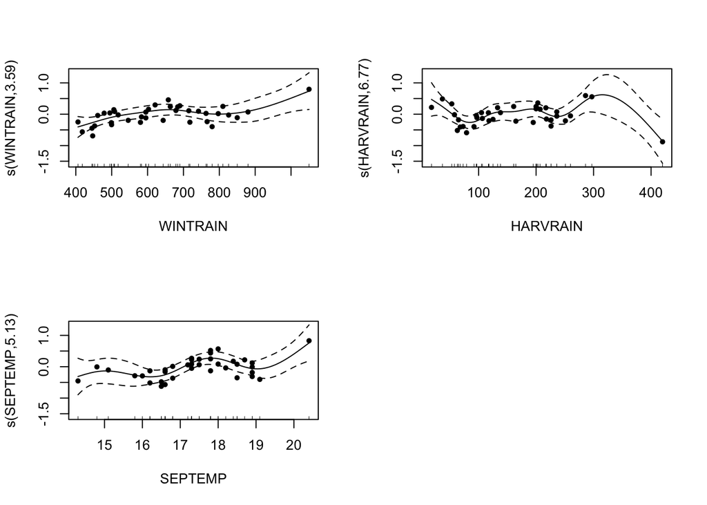

```r
par(mfrow=c(2,2))
plot(MG2,residuals=TRUE,pch=20)
```

**Mismo modelo pero con las variables ESCALADAS:**

Todo exactamente igual que en el modelo anterior, no parece que escalar las variables mejore en algo los modelos.

```r
MG4<-gam(PRICE ~  s(WINTRAINs) +  s(HARVRAINs) + SUMTEMPs + s(SEPTEMPs) + AREA, family=Gamma(link=log), data=datos)
summary(MG4)
```

```
##
## Family: Gamma
## Link function: log
##
## Formula:
## PRICE ~ s(WINTRAINs) + s(HARVRAINs) + SUMTEMPs + s(SEPTEMPs) +
##     AREA
##
## Parametric coefficients:
##             Estimate Std. Error t value Pr(>|t|)
## (Intercept)  3.63275    0.11304  32.137  < 2e-16 ***
## SUMTEMPs     0.26706    0.06081   4.391 0.000332 ***
## AREA2       -0.70940    0.16654  -4.260 0.000446 ***
## AREA3       -0.90409    0.18715  -4.831 0.000125 ***
## ---
## Signif. codes:  0 '***' 0.001 '**' 0.01 '*' 0.05 '.' 0.1 ' ' 1
##
## Approximate significance of smooth terms:
##                edf Ref.df     F p-value
## s(WINTRAINs) 3.592  4.352 3.412  0.0266 *
## s(HARVRAINs) 6.774  7.721 2.296  0.0671 .
## s(SEPTEMPs)  5.131  6.036 3.456  0.0181 *
## ---
## Signif. codes:  0 '***' 0.001 '**' 0.01 '*' 0.05 '.' 0.1 ' ' 1
##
## R-sq.(adj) =  0.845   Deviance explained = 90.3%
## GCV = 0.14665  Scale est. = 0.071547  n = 38
```

```r
AIC(MG4)
```

```
## [1] 254.8684
```

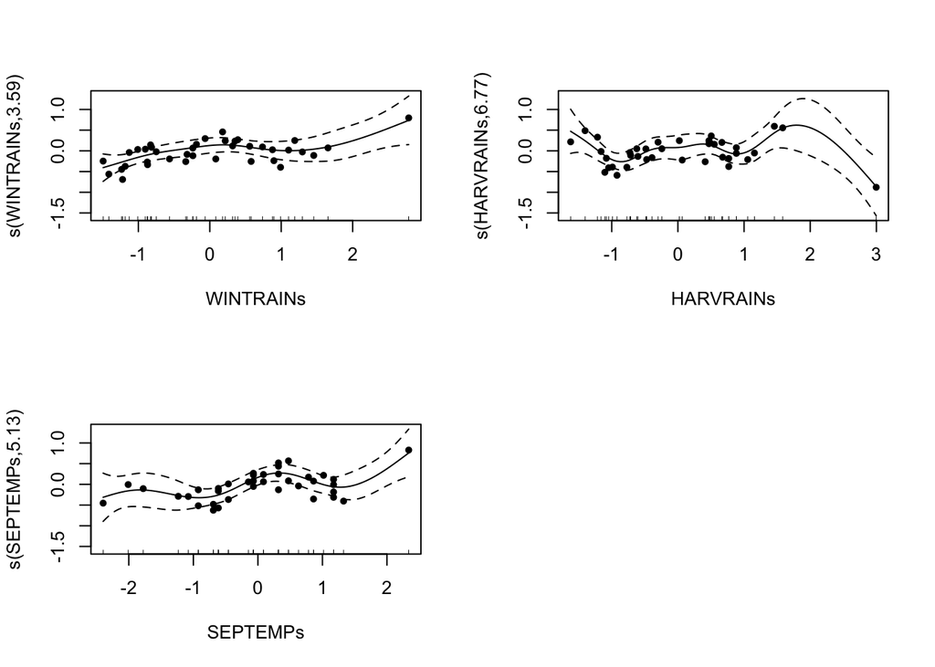

```r
par(mfrow=c(2,2))
plot(MG4,residuals=TRUE,pch=20)
```

**Modelo con todas las variables suavizadas cambiando las condiciones de spline:**

Este ajuste es mejor, bajando el AIC hasta 230. He probado a cambiar también el valor de k pero los modelos no mejoran este ajuste.

```r
MG6<-gam(PRICE ~ s(WINTRAIN, bs="cr") + s(HARVRAIN, bs="cr") + SUMTEMP + s(SEPTEMP, bs="cr") + AREA, family=Gamma(link=log), data=datos)
summary(MG6)
```

```
##
## Family: Gamma
## Link function: log
##
## Formula:
## PRICE ~ s(WINTRAIN, bs = "cr") + s(HARVRAIN, bs = "cr") + SUMTEMP +
##     s(SEPTEMP, bs = "cr") + AREA
##
## Parametric coefficients:
##             Estimate Std. Error t value Pr(>|t|)
## (Intercept) -1.06387    1.01528  -1.048 0.312298
## SUMTEMP      0.28307    0.06212   4.557 0.000438 ***
## AREA2       -0.90618    0.13498  -6.713 9.44e-06 ***
## AREA3       -0.73497    0.14924  -4.925 0.000218 ***
## ---
## Signif. codes:  0 '***' 0.001 '**' 0.01 '*' 0.05 '.' 0.1 ' ' 1
##
## Approximate significance of smooth terms:
##               edf Ref.df     F p-value
## s(WINTRAIN) 6.694  7.587 5.794 0.00216 **
## s(HARVRAIN) 8.726  8.950 5.874 0.00077 ***
## s(SEPTEMP)  4.453  5.258 5.928 0.00416 **
## ---
## Signif. codes:  0 '***' 0.001 '**' 0.01 '*' 0.05 '.' 0.1 ' ' 1
##
## R-sq.(adj) =  0.868   Deviance explained =   96%
## GCV = 0.10443  Scale est. = 0.038214  n = 38
```

```r
AIC(MG6)
```

```
## [1] 230.0793
```

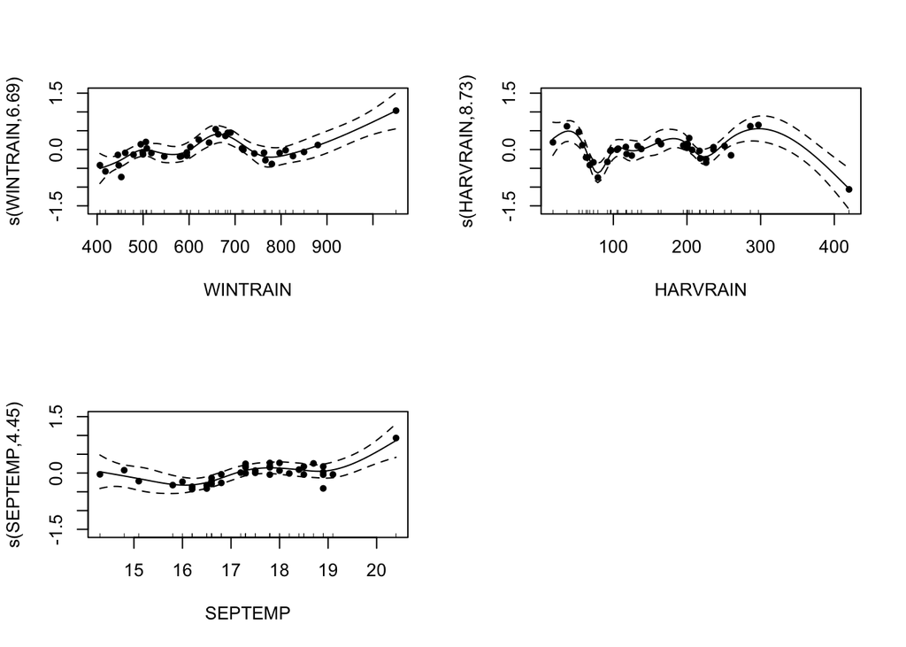

```r
par(mfrow=c(2,2))
plot(MG6,residuals=TRUE,pch=20)
```

**Mismo modelo pero con las variables escaladas:**

Seguimos sin apreciar ninguna mejora al escalar las variables.

```r
MG7<-gam(PRICE ~ s(WINTRAINs, bs="cr") + s(HARVRAINs, bs="cr") + SUMTEMPs + s(SEPTEMPs, bs="cr") + AREA, family=Gamma(link=log), data=datos)
summary(MG7)
```

```
##
## Family: Gamma
## Link function: log
##
## Formula:
## PRICE ~ s(WINTRAINs, bs = "cr") + s(HARVRAINs, bs = "cr") + SUMTEMPs +
##     s(SEPTEMPs, bs = "cr") + AREA
##
## Parametric coefficients:
##             Estimate Std. Error t value Pr(>|t|)
## (Intercept)  3.60761    0.08673  41.596 3.53e-16 ***
## SUMTEMPs     0.21856    0.04796   4.557 0.000438 ***
## AREA2       -0.90618    0.13498  -6.713 9.44e-06 ***
## AREA3       -0.73497    0.14924  -4.925 0.000218 ***
## ---
## Signif. codes:  0 '***' 0.001 '**' 0.01 '*' 0.05 '.' 0.1 ' ' 1
##
## Approximate significance of smooth terms:
##                edf Ref.df     F p-value
## s(WINTRAINs) 6.694  7.587 5.794 0.00216 **
## s(HARVRAINs) 8.726  8.950 5.874 0.00077 ***
## s(SEPTEMPs)  4.453  5.258 5.928 0.00416 **
## ---
## Signif. codes:  0 '***' 0.001 '**' 0.01 '*' 0.05 '.' 0.1 ' ' 1
##
## R-sq.(adj) =  0.868   Deviance explained =   96%
## GCV = 0.10443  Scale est. = 0.038214  n = 38
```

```r
AIC(MG7)
```

```
## [1] 230.0793
```

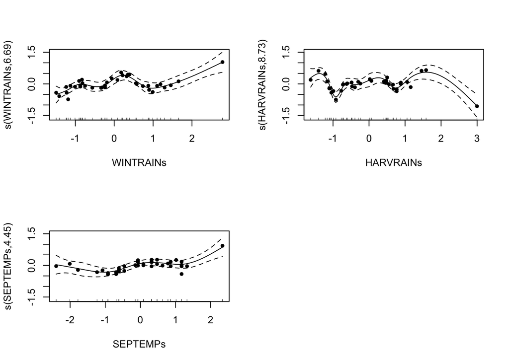

```r
par(mfrow=c(2,2))
plot(MG7,residuals=TRUE,pch=20)
```

### *Modelos Aditivos Generalizados Mixtos*

**Partimos de modelo con suavizado para SEPTEMP, WINTRAIN y HARVRAIN y como factor de efectos aleatorios AREA**

De nuevo, consideramos AREA como factor de efectos aleatorios. Tenemos un AIC de 56, buen modelo en general. Las gráficas de los residuos no terminan de convencer, la normalidad no está clara y parece que la varianza no es constante. El coeficiente para la variable HARVRAIN sale no significativo.

```r
gamm1 <- gamm(PRICE ~ s(WINTRAIN, bs="cr") + s(HARVRAIN, bs="cr") + SUMTEMP + s(SEPTEMP, bs="cr"), data = datos, random=list(AREA=~1), family=Gamma(link="log"))
```

```
##
##  Maximum number of PQL iterations:  20
```

```
## iteration 1
```

```
## iteration 2
```

```
## iteration 3
```

```
## iteration 4
```

```
## iteration 5
```

```
## iteration 6
```

```r
summary(gamm1[[1]])
```

```
## Linear mixed-effects model fit by maximum likelihood
##  Data: data
##        AIC      BIC    logLik
##   56.60216 72.97802 -18.30108
##
## Random effects:
##  Formula: ~Xr - 1 | g
##  Structure: pdIdnot
##                  Xr1          Xr2          Xr3          Xr4          Xr5
## StdDev: 1.890932e-05 1.890932e-05 1.890932e-05 1.890932e-05 1.890932e-05
##                  Xr6          Xr7          Xr8
## StdDev: 1.890932e-05 1.890932e-05 1.890932e-05
##
##  Formula: ~Xr.0 - 1 | g.0 %in% g
##  Structure: pdIdnot
##                Xr.01        Xr.02        Xr.03        Xr.04        Xr.05
## StdDev: 1.464635e-05 1.464635e-05 1.464635e-05 1.464635e-05 1.464635e-05
##                Xr.06        Xr.07        Xr.08
## StdDev: 1.464635e-05 1.464635e-05 1.464635e-05
##
##  Formula: ~Xr.1 - 1 | g.1 %in% g.0 %in% g
##  Structure: pdIdnot
##               Xr.11       Xr.12       Xr.13       Xr.14       Xr.15       Xr.16
## StdDev: 0.004975547 0.004975547 0.004975547 0.004975547 0.004975547 0.004975547
##               Xr.17       Xr.18
## StdDev: 0.004975547 0.004975547
##
##  Formula: ~1 | AREA %in% g.1 %in% g.0 %in% g
##         (Intercept)  Residual
## StdDev:   0.3110614 0.3557215
##
## Variance function:
##  Structure: fixed weights
##  Formula: ~invwt
## Fixed effects: list(fixed)
##                     Value Std.Error DF   t-value p-value
## X(Intercept)    -3.235755 1.4871338 31 -2.175833  0.0373
## XSUMTEMP         0.386759 0.0894020 31  4.326067  0.0001
## Xs(WINTRAIN)Fx1  0.633173 0.2656122 31  2.383826  0.0234
## Xs(HARVRAIN)Fx1  0.215835 0.2705812 31  0.797673  0.4311
## Xs(SEPTEMP)Fx1  -0.922569 0.2896314 31 -3.185320  0.0033
##  Correlation:
##                 X(Int) XSUMTE X(WINT X(HARV
## XSUMTEMP        -0.991
## Xs(WINTRAIN)Fx1 -0.182  0.184
## Xs(HARVRAIN)Fx1 -0.250  0.252 -0.078
## Xs(SEPTEMP)Fx1  -0.179  0.179  0.127  0.216
##
## Standardized Within-Group Residuals:
##         Min          Q1         Med          Q3         Max
## -1.60259611 -0.82160634 -0.09525949  0.92168105  1.86527380
##
## Number of Observations: 38
## Number of Groups:
##                             g                    g.0 %in% g
##                             1                             1
##           g.1 %in% g.0 %in% g AREA %in% g.1 %in% g.0 %in% g
##                             1                             3
```

```r
summary(gamm1[[2]])
```

```
##
## Family: Gamma
## Link function: log
##
## Formula:
## PRICE ~ s(WINTRAIN, bs = "cr") + s(HARVRAIN, bs = "cr") + SUMTEMP +
##     s(SEPTEMP, bs = "cr")
##
## Parametric coefficients:
##             Estimate Std. Error t value Pr(>|t|)
## (Intercept)  -3.2358     1.4238  -2.273   0.0297 *
## SUMTEMP       0.3868     0.0856   4.518 7.65e-05 ***
## ---
## Signif. codes:  0 '***' 0.001 '**' 0.01 '*' 0.05 '.' 0.1 ' ' 1
##
## Approximate significance of smooth terms:
##               edf Ref.df     F p-value
## s(WINTRAIN) 1.000  1.000 6.199 0.01791 *
## s(HARVRAIN) 1.000  1.000 0.694 0.41076
## s(SEPTEMP)  1.209  1.209 8.570 0.00328 **
## ---
## Signif. codes:  0 '***' 0.001 '**' 0.01 '*' 0.05 '.' 0.1 ' ' 1
##
## R-sq.(adj) =  0.0956
##   Scale est. = 0.12654   n = 38
```

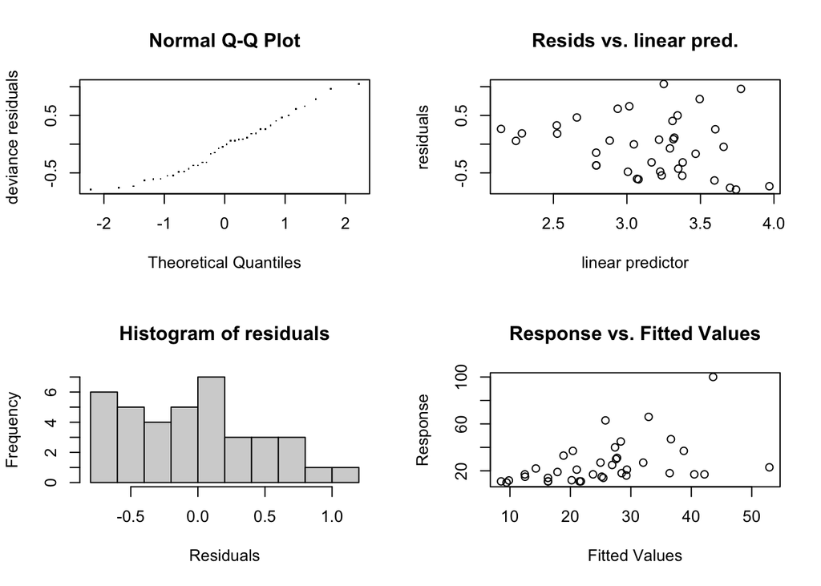

```
##
## 'gamm' based fit - care required with interpretation.
## Checks based on working residuals may be misleading.
## Basis dimension (k) checking results. Low p-value (k-index<1) may
## indicate that k is too low, especially if edf is close to k'.
##
##               k'  edf k-index p-value
## s(WINTRAIN) 9.00 1.00    0.81   0.130
## s(HARVRAIN) 9.00 1.00    0.86   0.175
## s(SEPTEMP)  9.00 1.21    0.78   0.065 .
## ---
## Signif. codes:  0 '***' 0.001 '**' 0.01 '*' 0.05 '.' 0.1 ' ' 1
```

```r
par(mfrow=c(2,2))
gam.check(gamm1$gam)
```

**Mismo modelo sin la variable HARVRAIN**

En este caso, el AIC es de 55 y el suavizado para la variable WINTRAIN parece no ser necesario (edf de 1).

```r
gamm2 <- gamm(PRICE ~ s(WINTRAIN, bs="cr") + SUMTEMP + s(SEPTEMP, bs="cr"), data = datos, random=list(AREA=~1), family=Gamma(link="log"))
```

```
##
##  Maximum number of PQL iterations:  20
```

```
## iteration 1
```

```
## iteration 2
```

```
## iteration 3
```

```
## iteration 4
```

```
## iteration 5
```

```
## iteration 6
```

```
## iteration 7
```

```
## iteration 8
```

```
## iteration 9
```

```
## iteration 10
```

```
## iteration 11
```

```
## iteration 12
```

```
## iteration 13
```

```
## iteration 14
```

```
## iteration 15
```

```
## iteration 16
```

```
## iteration 17
```

```
## iteration 18
```

```
## iteration 19
```

```
## iteration 20
```

```r
summary(gamm2[[1]])
```

```
## Linear mixed-effects model fit by maximum likelihood
##  Data: data
##        AIC     BIC    logLik
##   54.57451 67.6752 -19.28725
##
## Random effects:
##  Formula: ~Xr - 1 | g
##  Structure: pdIdnot
##                  Xr1          Xr2          Xr3          Xr4          Xr5
## StdDev: 1.385334e-06 1.385334e-06 1.385334e-06 1.385334e-06 1.385334e-06
##                  Xr6          Xr7          Xr8
## StdDev: 1.385334e-06 1.385334e-06 1.385334e-06
##
##  Formula: ~Xr.0 - 1 | g.0 %in% g
##  Structure: pdIdnot
##              Xr.01      Xr.02      Xr.03      Xr.04      Xr.05      Xr.06
## StdDev: 0.04855267 0.04855267 0.04855267 0.04855267 0.04855267 0.04855267
##              Xr.07      Xr.08
## StdDev: 0.04855267 0.04855267
##
##  Formula: ~1 | AREA %in% g.0 %in% g
##         (Intercept)  Residual
## StdDev:   0.3130989 0.3359583
##
## Variance function:
##  Structure: fixed weights
##  Formula: ~invwt
## Fixed effects: list(fixed)
##                     Value Std.Error DF   t-value p-value
## X(Intercept)    -2.554263 1.3813717 32 -1.849078  0.0737
## XSUMTEMP         0.345613 0.0829402 32  4.167016  0.0002
## Xs(WINTRAIN)Fx1  0.607403 0.2500594 32  2.429035  0.0209
## Xs(SEPTEMP)Fx1  -1.031114 0.2881646 32 -3.578212  0.0011
##  Correlation:
##                 X(Int) XSUMTE X(WINT
## XSUMTEMP        -0.989
## Xs(WINTRAIN)Fx1 -0.216  0.219
## Xs(SEPTEMP)Fx1  -0.078  0.077  0.132
##
## Standardized Within-Group Residuals:
##        Min         Q1        Med         Q3        Max
## -1.4757939 -0.7316343 -0.2372551  0.7565464  1.9309389
##
## Number of Observations: 38
## Number of Groups:
##                    g           g.0 %in% g AREA %in% g.0 %in% g
##                    1                    1                    3
```

```r
summary(gamm2[[2]])
```

```
##
## Family: Gamma
## Link function: log
##
## Formula:
## PRICE ~ s(WINTRAIN, bs = "cr") + SUMTEMP + s(SEPTEMP, bs = "cr")
##
## Parametric coefficients:
##             Estimate Std. Error t value Pr(>|t|)
## (Intercept)  -2.5543     1.3424  -1.903 0.066324 .
## SUMTEMP       0.3456     0.0806   4.288 0.000161 ***
## ---
## Signif. codes:  0 '***' 0.001 '**' 0.01 '*' 0.05 '.' 0.1 ' ' 1
##
## Approximate significance of smooth terms:
##               edf Ref.df     F p-value
## s(WINTRAIN) 1.000  1.000 6.247 0.01777 *
## s(SEPTEMP)  3.725  3.725 5.268 0.00298 **
## ---
## Signif. codes:  0 '***' 0.001 '**' 0.01 '*' 0.05 '.' 0.1 ' ' 1
##
## R-sq.(adj) =  0.249
##   Scale est. = 0.11287   n = 38
```

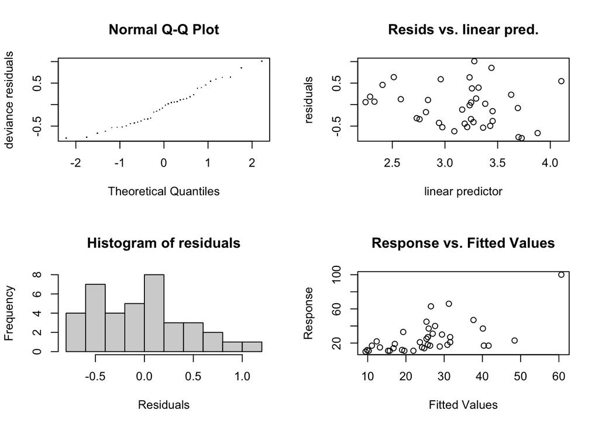

```
##
## 'gamm' based fit - care required with interpretation.
## Checks based on working residuals may be misleading.
## Basis dimension (k) checking results. Low p-value (k-index<1) may
## indicate that k is too low, especially if edf is close to k'.
##
##               k'  edf k-index p-value
## s(WINTRAIN) 9.00 1.00    0.85    0.17
## s(SEPTEMP)  9.00 3.73    0.79    0.06 .
## ---
## Signif. codes:  0 '***' 0.001 '**' 0.01 '*' 0.05 '.' 0.1 ' ' 1
```

```r
par(mfrow=c(2,2))
gam.check(gamm2$gam)
```

**Mismo modelo sin la variable WINTRAIN suavizada**

Tenemos un AIC de 52 con todos los coeficientes significativos, modelo definitivo. Las gráficas de los residuos del gam.check no son perfectas, la varianza no parece del todo homogénea.

```r
gamm3 <- gamm(PRICE ~ SUMTEMP + WINTRAIN + s(SEPTEMP, bs="cr"), data = datos, random=list(AREA=~1), family=Gamma(link="log"))
```

```
##
##  Maximum number of PQL iterations:  20
```

```
## iteration 1
```

```
## iteration 2
```

```
## iteration 3
```

```
## iteration 4
```

```
## iteration 5
```

```r
summary(gamm3[[1]])
```

```
## Linear mixed-effects model fit by maximum likelihood
##  Data: data
##        AIC      BIC    logLik
##   51.93048 63.39358 -18.96524
##
## Random effects:
##  Formula: ~Xr - 1 | g
##  Structure: pdIdnot
##                Xr1        Xr2        Xr3        Xr4        Xr5        Xr6
## StdDev: 0.04198843 0.04198843 0.04198843 0.04198843 0.04198843 0.04198843
##                Xr7        Xr8
## StdDev: 0.04198843 0.04198843
##
##  Formula: ~1 | AREA %in% g
##         (Intercept)  Residual
## StdDev:   0.3115053 0.3368256
##
## Variance function:
##  Structure: fixed weights
##  Formula: ~invwt
## Fixed effects: list(fixed)
##                    Value Std.Error DF   t-value p-value
## X(Intercept)   -3.309028 1.4604539 32 -2.265753  0.0304
## XSUMTEMP        0.351092 0.0827385 32  4.243398  0.0002
## XWINTRAIN       0.001033 0.0004298 32  2.403451  0.0222
## Xs(SEPTEMP)Fx1 -0.982656 0.2869337 32 -3.424679  0.0017
##  Correlation:
##                X(Int) XSUMTE XWINTR
## XSUMTEMP       -0.974
## XWINTRAIN      -0.389  0.218
## Xs(SEPTEMP)Fx1 -0.101  0.080  0.132
##
## Standardized Within-Group Residuals:
##        Min         Q1        Med         Q3        Max
## -1.5358491 -0.7213623 -0.1868898  0.7559172  1.8886071
##
## Number of Observations: 38
## Number of Groups:
##           g AREA %in% g
##           1           3
```

```r
summary(gamm3[[2]])
```

```
##
## Family: Gamma
## Link function: log
##
## Formula:
## PRICE ~ SUMTEMP + WINTRAIN + s(SEPTEMP, bs = "cr")
##
## Parametric coefficients:
##               Estimate Std. Error t value Pr(>|t|)
## (Intercept) -3.3090277  1.4394391  -2.299 0.028301 *
## SUMTEMP      0.3510923  0.0815479   4.305 0.000151 ***
## WINTRAIN     0.0010330  0.0004236   2.439 0.020570 *
## ---
## Signif. codes:  0 '***' 0.001 '**' 0.01 '*' 0.05 '.' 0.1 ' ' 1
##
## Approximate significance of smooth terms:
##              edf Ref.df     F p-value
## s(SEPTEMP) 3.487  3.487 4.625 0.00632 **
## ---
## Signif. codes:  0 '***' 0.001 '**' 0.01 '*' 0.05 '.' 0.1 ' ' 1
##
## R-sq.(adj) =  0.197
##   Scale est. = 0.11345   n = 38
```

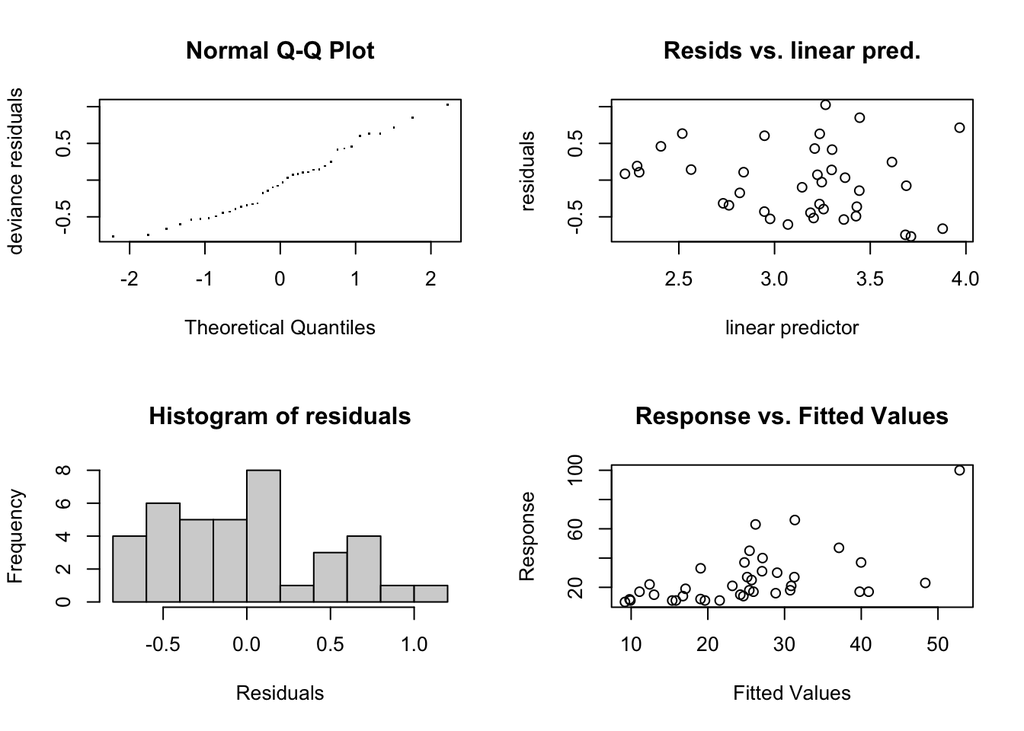

```
##
## 'gamm' based fit - care required with interpretation.
## Checks based on working residuals may be misleading.
## Basis dimension (k) checking results. Low p-value (k-index<1) may
## indicate that k is too low, especially if edf is close to k'.
##
##              k'  edf k-index p-value
## s(SEPTEMP) 9.00 3.49    0.79    0.12
```

```r
par(mfrow=c(2,2))
gam.check(gamm3$gam)
```

### *Predicción*

[output not shown]